# HUDK5124Assignment10

Zhuqian Zhou

2017/4/9

# 1

**For either the sports data or the furniture data (both rated similarity, collected by Rosch et al.) posted in this session, fit an ultrametric tree to the data using the iterative projection method offered in R’s “ls_fit_ultrametric” routine (see method below, also see posted help file “R_fitting trees to prox data.txt”). Calculate the (squared) correlation of the model distances to the data, RSQ.**

```r
library(clue)
f1 <- read.table("FURN_prx_revised.txt", fill = TRUE, header = TRUE) # add zero on diagonal before read the table
rownames(f1) <- names(f1)
f2 <- as.matrix(f1)
ultraD=ls_fit_ultrametric(f2,method=c("IP"), weights = 1, control = list()) # fit an ultrametric tree (LS solution, by iterative projection) to a data set
```

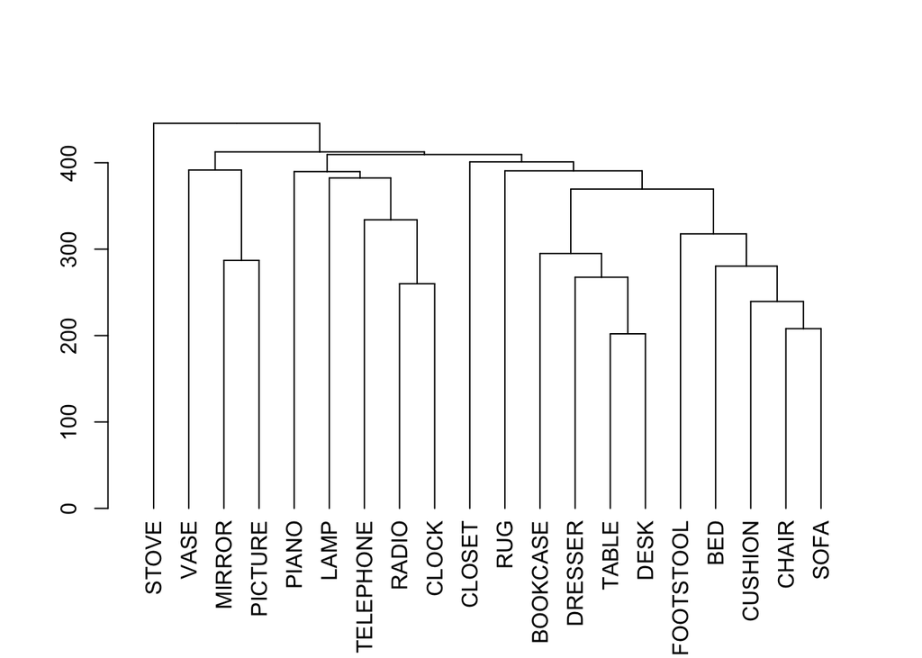

```r
hc <- hclust(ultraD, "ave") # method="average"
dend1 <- as.dendrogram(hc) # "print()" method
plot(dend1)
```

```r
# calculate the "cophenetic correlation" - the corr of data & model distances
library(gdata)
datvec = as.vector(lowerTriangle(f2, diag=FALSE)) # Function lowerTriangle() is in Package "gdata"
modvec = as.vector(ultraD)
cor(datvec,modvec)
```

```
## [1] 0.8035247
```